# Final Project

Sarah Running

2026-10-01

### **Introduction**

Diabetes is a chronic health condition that can be associated with a variety of demographic, behavioral, and health-related factors. The Behavioral Risk Factor Surveillance System (BRFSS) is a large health survey that collects information about health conditions, health behaviors, and other characteristics of adults in the United States. This analysis uses data from the 2015 BRFSS diabetes dataset to examine factors associated with diabetes status.

The dataset includes information on whether respondents have diabetes or prediabetes, as well as health behaviors and characteristics such as BMI, physical activity, high blood pressure, age, and general health. In this analysis, BMI will be compared across three diabetes status groups: respondents without diabetes, respondents with prediabetes, and respondents with diabetes. Summary statistics and a boxplot will be used to describe differences in BMI across these groups.

**Table 1. Characteristics of respondents by diabetes status**

| **Characteristic** | **No diabetes** N = 213,703<sup>1</sup> | **Prediabetes** N = 4,631<sup>1</sup> | **Diabetes** N = 35,346<sup>1</sup> |
| --- | --- | --- | --- |
| Body Mass Index | 28 (6) | 31 (7) | 32 (7) |
| High Blood Pressure | 79,312 (37%) | 2,913 (63%) | 26,604 (75%) |
| Physical Activity | 166,491 (78%) | 3,142 (68%) | 22,287 (63%) |
| Sex | 92,744 (43%) | 2,027 (44%) | 16,935 (48%) |

<sup>1</sup> Mean (SD); n (%)

Table 1 summarizes selected demographic and health characteristics of respondents by diabetes status. BMI is reported as the mean and standard deviation and categorical variables are reported as counts and percentages.

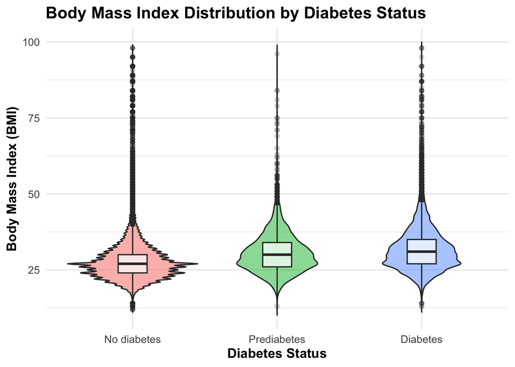

Figure 1. Distribution of body mass index (BMI) by diabetes status.